# Post 01

Data Visualization: exploring more about ggplot2

# Introduction

- The idea of “ggplot2” is introduced as as a more advanced plotting method in addition to the base R pakage. The “gg” in ggplot2 stands for the Grammar of Graphics, a comprehensive theory of graphics by Lee Wilkinson which he described in his book by the same name.
- In Wilkinson’s book, *The Grammar of Graphics*, he showed how we could describe plots not as discrete types like bar plot or pie chart, but using a “grammar” that would work not only for plots we commonly use but for almost any conceivable graphic. From this perspective, a pie chart is just a bar chart with a circular (polar) coordinate system replacing the rectangular Cartesian coordinate system.

# Background

### Here are some basic terminologies we’ve learned so far about ggplot.

- - **ggplot** - The main function where you specify the dataset and variables to plot.
  - **geoms** - The geomatric objects
    - *Examples*: geom_point(), geom_bar(), geom_density(), geom_line(), etc.
  - **aes** - The aesthetics
    - *Examples*: shape, transparency(alpha), color, fill, linetype, etc.
  - **scales** - Defines how the data will be plotted.
    - *Examples*: continuous, discrete, log, etc.

### Examples: assembling the ggplot

### The dataset of 2017 NBA players.

```r
players <- read.csv('/Users/Jade/stat133-hws-fall17/post01/data/nba2017-players.csv')

head(players, 3)
```

```
##          player team position height weight age experience
## 1    Al Horford  BOS        C     82    245  30          9
## 2  Amir Johnson  BOS       PF     81    240  29         11
## 3 Avery Bradley  BOS       SG     74    180  26          6
##                         college   salary games minutes points points3
## 1         University of Florida 26540100    68    2193    952      86
## 2                               12000000    80    1608    520      27
## 3 University of Texas at Austin  8269663    55    1835    894     108
##   points2 points1
## 1     293     108
## 2     186      67
## 3     251      68
```

### Basic Scatterplot

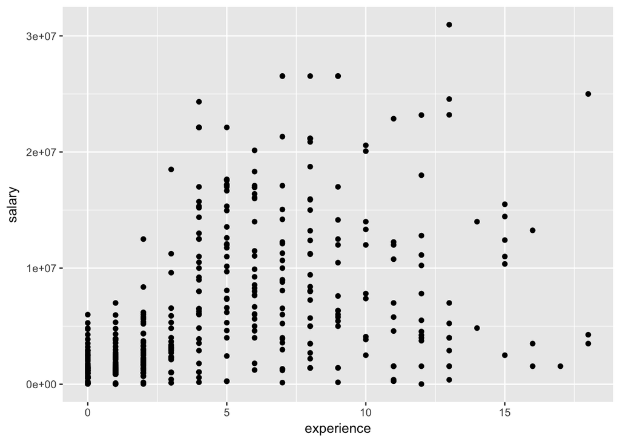

```r
library('ggplot2')
myplot <- ggplot(data = players, aes(x = experience, y = salary)) + geom_point()

myplot
```